# Szachy w erze cyfrowej

Wpływ mediów społecznościowych i internetu na popularyzacje szachów, jak te dane wykorzystać i jak wprowadzić nowość w szachach.

Rafal Bazan

2024-05-21

# Początkowe ustawienia

#### Css

```css
.my_button {
  background-color: #caa8b1;
  color: #3c2a34;
  padding: 10px;
  font-size: 14px;
  border: none;
  cursor: pointer;
  width: 70px;
}
h1, h2, h3, h4, h5, h6 {
      text-align: center;
      color: #e0cdd6;
    }
body {
  background-color: #3c2a34;
}
table {
   margin:1em auto;
   color: #e0cdd6;
}
```

#### Definiowanie ścieżek

```r
project_path = "C:/Users/rafal/moje_2024-07-02/moje/projekty/chess-in-the-digital-age"
setwd(paste(project_path,"/presentation", sep = ""))
Dataset_path = paste(project_path,"/Dataset", sep = "")
selected_date = "2024-04"

knitr::opts_chunk$set(root= paste(project_path,"/presentation", sep = ""))
```

#### Definiowanie paczek

```r
library(pander)
panderOptions('digits',7)
library(knitr)
library(rvest)
library(stringi)
library(dplyr)
library(scales)
library(ggplot2)
library(png)
library("patchwork")
library(forcats)
img <- readPNG("../pictures/queens_gambit.png", native = TRUE)
img2 = readPNG("../pictures/candidates_tournament.png", native = TRUE)
img3 = readPNG("../pictures/covid.png", native = TRUE)
img4 = readPNG("../pictures/opening_icon.png", native = TRUE)
```

#### Wybór tablicy do scrapowania

```r
url = "https://database.lichess.org"
path= "/html/body/div/div[2]/div[2]/section[1]/table"
wezel = html_node(read_html(url), xpath=path)
```

#### Java-script dla przycisku

```javascript
const div_my_init = document.getElementById("my_init");
  div_init.style.display = 'none';

var button_my_init = document.getElementById("button_my_init");

function hideMy_init() {
  if (div_my_init.style.display === 'none') {
    div_my_init.style.display = 'block';
    button_my_init.innerHTML = "Ukryj";
  } else {
    div_my_init.style.display = 'none';
    button_my_init.innerHTML = "Pokaż";
  }
}
```

# Czy szachy są coraz popularniejsze?

[figure not shown]

### Scrapowanie danych z lichess

```r
# wybor tabeli z iloscia zagranych partii wedlug miesiaca
games_count_html = html_table(wezel)[[3]]

my_games_count <- data.frame(count=as.numeric(stri_replace_all(games_count_html,"",regex = "\\,"))[-length(games_count_html)])

# wybor lat do analizy na podstawie linkow .zst.torrent
hyperlinks = html_nodes(wezel, "a")
my_href = html_attr(hyperlinks, "href")
links = data.frame(links = paste(url,my_href,sep="/"))
#####
choose_max_date_to_scrap1 = function(date){

  # co drugi link to .zst.torrent wiec go wyodrebniam
  init_links_for_download = links[seq(2,nrow(links), by=2), 1]

  full_date_from_imported_links = data.frame(stri_match_all(data.frame(init_links_for_download),
                                     regex = "rated_\\s*(.*?)\\s*[.]"))[,2]

  date_location = which(stri_detect(full_date_from_imported_links, regex = date) == TRUE)

  my_links_for_download = init_links_for_download[c(date_location:length(init_links_for_download))]

  return(my_links_for_download)
}

init_links_for_download = choose_max_date_to_scrap1(selected_date)

choose_max_date_to_scrap_game_count1 = function(date){
  # wybor tabeli do analizy
  my_games_count = html_table(wezel)[[3]]

  # wybor lat do analizy na podstawie linkow .zst.torrent
  init_links_for_download = links[seq(2,nrow(links), by=2), 1]

  # wyodrebnianie dat z linkow
  full_date_from_imported_links = data.frame(stri_match_all(data.frame(init_links_for_download),
                                     regex = "rated_\\s*(.*?)\\s*[.]"))[,2]

  # szukanie indeksow z datami odpowiadajacymi wybranej dacie
  date_location = which(stri_detect(full_date_from_imported_links, regex = date) == TRUE)

  # wyswietlanie liczb gier dla wybranych dat
  games_count = my_games_count[c(date_location:length(init_links_for_download))]

  return(games_count)
}

games_count_html = choose_max_date_to_scrap_game_count1(selected_date)
my_games_count <- data.frame(count=as.numeric(stri_replace_all(games_count_html,"",regex = "\\,")))
# wyodrebnianie lat z linkow

my_year_from_imported_links = data.frame(year=data.frame(stri_match_all(data.frame(init_links_for_download),
                                   regex = "rated_\\s*(.*?)\\s*[-]"))[,2])


Data_games_count = cbind(my_year_from_imported_links,my_games_count)

# szukanie indeksow rozpoczynajacych nowy rok w zbiorze
first_index_of_years=c()

for(i in unique(my_year_from_imported_links)[,]){
first_index_of_years = append(first_index_of_years,which(rev(Data_games_count$year)==i)[1])
}
```

### Wizualizacja

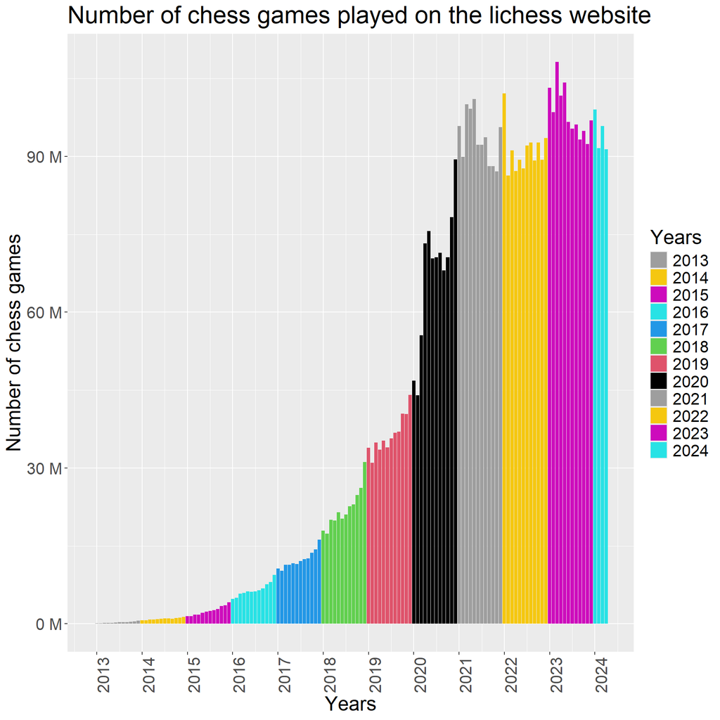

```r
my_plot = ggplot(Data_games_count, aes(x = rev(1:nrow(data.frame(my_games_count))), y = count)) +

  # typ wykresu
  geom_bar(stat = "identity",aes(fill = year)) +

  # opis
  labs(x = "Years", y = "Number of chess games", title = "Number of chess games played on the lichess website") +

  # legenda
  scale_fill_manual(name = "Years", values = unique(Data_games_count$year)) +
  expand_limits(x = c(0, NA), y = c(0,NA)) +
  scale_x_continuous(breaks = c(rev(first_index_of_years)),
                     labels = c(rev(unique(my_year_from_imported_links)[,]))) +
  scale_y_continuous(labels = unit_format(unit = "M", scale = 1e-6)) +
  theme(text = element_text(size = 20),
        axis.text.x = element_text(angle = 90, hjust = 1))
my_plot
```

```r
ggsave("../poster/Data_games_countv1.png")
```

#### Szukanie powodów znacznego wzrostu popularności szachów w 2020 roku

[figure not shown]

```r
# strzalka

my_plot + geom_segment(aes(70, 68000000, xend = 86, yend = 62000000),
               linewidth=1.2,
               arrow = arrow(length = unit(5, "mm"))) +

  # zdjecia
    inset_element(p = img,
                left = 0.02,
                bottom = 0.54,
                right = 0.42,
                top = 0.9) +
  inset_element(p = img2,
                left = 0.05,
                bottom = 0.29,
                right = 0.5,
                top = 0.52)+
  inset_element(p = img3,
                left = 0.44,
                bottom = 0.69,
                right = 0.65,
                top = 0.82)
```

```r
ggsave("../poster/Data_games_count.png")
```

### Wnioski:

- Szachy zyskują na popularności, ale czy na pewno dzięki internetowi i cyfryzacji?

# Jak wpłynął serial “Gambit królowej” na popularyzacje szachów?

#### Ciekawostka:

- “Gambit królowej” to również nazwa debiutu szachowego. Debiut szachowy z kolei to początkowe posunięcia w szachach.

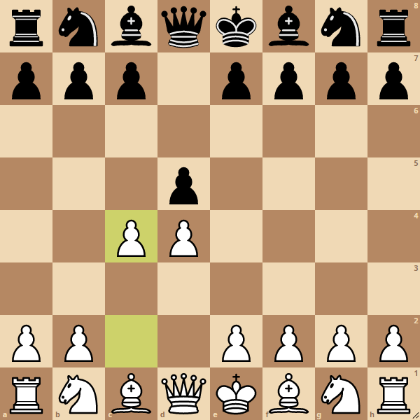

*Gambit Królowej*

### Ile było granych debiutów “Gambit królowej”?

# Tworzenie struktury zbioru danych

#### wyodrębnianie tagów oraz hiperłączy

```r
hyperlinks = html_nodes(wezel, "a")
my_href = html_attr(hyperlinks, "href")

pander(head(bind_rows(lapply(html_attrs(hyperlinks), function(x) data.frame(as.list(x), stringsAsFactors=FALSE)))))
```

| href |
| --- |
| standard/lichess_db_standard_rated_2025-04.pgn.zst |
| standard/lichess_db_standard_rated_2025-04.pgn.zst.torrent |
| standard/lichess_db_standard_rated_2025-03.pgn.zst |
| standard/lichess_db_standard_rated_2025-03.pgn.zst.torrent |
| standard/lichess_db_standard_rated_2025-02.pgn.zst |
| standard/lichess_db_standard_rated_2025-02.pgn.zst.torrent |

#### Łączenie zmiennych w gotowy do pobrania link

```r
links = data.frame(links = paste(url,my_href,sep="/"))
pander(head(links))
```

| links |
| --- |
| https://database.lichess.org/standard/lichess_db_standard_rated_2025-04.pgn.zst |
| https://database.lichess.org/standard/lichess_db_standard_rated_2025-04.pgn.zst.torrent |
| https://database.lichess.org/standard/lichess_db_standard_rated_2025-03.pgn.zst |
| https://database.lichess.org/standard/lichess_db_standard_rated_2025-03.pgn.zst.torrent |
| https://database.lichess.org/standard/lichess_db_standard_rated_2025-02.pgn.zst |
| https://database.lichess.org/standard/lichess_db_standard_rated_2025-02.pgn.zst.torrent |

#### Wybór wersji pobierania (.zst.torrent) w funkcji ograniczającej scrapowanie względem wybranej daty

```r
choose_max_date_to_scrap = function(date){

  # co drugi link to .zst.torrent wiec go wyodrebniam
  init_links_for_download = links[seq(2,nrow(links), by=2), 1]

  full_date_from_imported_links = data.frame(stri_match_all(data.frame(init_links_for_download),
                                     regex = "rated_\\s*(.*?)\\s*[.]"))[,2]

  date_location = which(stri_detect(full_date_from_imported_links, regex = date) == TRUE)

  my_links_for_download = init_links_for_download[c(date_location:length(init_links_for_download))]

  return(my_links_for_download)
}

links_for_download = choose_max_date_to_scrap(selected_date)
pander(data.frame(prepared_links = head(links_for_download)))
```

| prepared_links |
| --- |
| https://database.lichess.org/standard/lichess_db_standard_rated_2024-04.pgn.zst.torrent |
| https://database.lichess.org/standard/lichess_db_standard_rated_2024-03.pgn.zst.torrent |
| https://database.lichess.org/standard/lichess_db_standard_rated_2024-02.pgn.zst.torrent |
| https://database.lichess.org/standard/lichess_db_standard_rated_2024-01.pgn.zst.torrent |
| https://database.lichess.org/standard/lichess_db_standard_rated_2023-12.pgn.zst.torrent |
| https://database.lichess.org/standard/lichess_db_standard_rated_2023-11.pgn.zst.torrent |

#### Wyodrębianie daty ze scrapowania

```r
full_date_from_imported_links = data.frame(stri_match_all(data.frame(links_for_download),
                                     regex = "rated_\\s*(.*?)\\s*[.]"))[,2]
pander(head(data.frame(full_date_from_imported_links)))
```

| full_date_from_imported_links |
| --- |
| 2024-04 |
| 2024-03 |
| 2024-02 |
| 2024-01 |
| 2023-12 |
| 2023-11 |

#### Wyodrębianie roku, miesięcy, nazw miesięcy ze scrapowania

```r
year_from_imported_links = data.frame(stri_match_all(data.frame(links_for_download),
                                     regex = "rated_\\s*(.*?)\\s*[-]"))[,2]
pander(head(data.frame(year_from_imported_links)))
```

| year_from_imported_links |
| --- |
| 2024 |
| 2024 |
| 2024 |
| 2024 |
| 2023 |
| 2023 |

```r
month_from_imported_links = data.frame(stri_match_all(data.frame(links_for_download),
                                     regex = "-\\s*(.*?)\\s*[.]"))[,2]
pander(head(data.frame(month_from_imported_links)))
```

| month_from_imported_links |
| --- |
| 04 |
| 03 |
| 02 |
| 01 |
| 12 |
| 11 |

```r
my_month_names = month.abb[as.integer(month_from_imported_links)]
pander(head(data.frame(my_month_names)))
```

| my_month_names |
| --- |
| Apr |
| Mar |
| Feb |
| Jan |
| Dec |
| Nov |

#### Tworzenie struktury plików - lata

```r
my_paths_year <- unique(paste(Dataset_path,"/",year_from_imported_links, sep=""))
pander(data.frame(my_paths_year))
```

| my_paths_year |
| --- |
| C:/Users/rafal/moje_2024-07-02/moje/projekty/chess-in-the-digital-age/Dataset/2024 |
| C:/Users/rafal/moje_2024-07-02/moje/projekty/chess-in-the-digital-age/Dataset/2023 |
| C:/Users/rafal/moje_2024-07-02/moje/projekty/chess-in-the-digital-age/Dataset/2022 |
| C:/Users/rafal/moje_2024-07-02/moje/projekty/chess-in-the-digital-age/Dataset/2021 |
| C:/Users/rafal/moje_2024-07-02/moje/projekty/chess-in-the-digital-age/Dataset/2020 |
| C:/Users/rafal/moje_2024-07-02/moje/projekty/chess-in-the-digital-age/Dataset/2019 |
| C:/Users/rafal/moje_2024-07-02/moje/projekty/chess-in-the-digital-age/Dataset/2018 |
| C:/Users/rafal/moje_2024-07-02/moje/projekty/chess-in-the-digital-age/Dataset/2017 |
| C:/Users/rafal/moje_2024-07-02/moje/projekty/chess-in-the-digital-age/Dataset/2016 |
| C:/Users/rafal/moje_2024-07-02/moje/projekty/chess-in-the-digital-age/Dataset/2015 |
| C:/Users/rafal/moje_2024-07-02/moje/projekty/chess-in-the-digital-age/Dataset/2014 |
| C:/Users/rafal/moje_2024-07-02/moje/projekty/chess-in-the-digital-age/Dataset/2013 |

```r
create_folders_year = function(){
  for(i in 1:length(my_paths_year)){
    dir.create(my_paths_year[i])
  }
}
```

#### Tworzenie struktury plików - miesiące

```r
my_paths_month <- paste(Dataset_path,"/",year_from_imported_links,"/",month_from_imported_links,". ",my_month_names, sep="")
pander(head(data.frame(my_paths_month)))
```

| my_paths_month |
| --- |
| C:/Users/rafal/moje_2024-07-02/moje/projekty/chess-in-the-digital-age/Dataset/2024/04. Apr |
| C:/Users/rafal/moje_2024-07-02/moje/projekty/chess-in-the-digital-age/Dataset/2024/03. Mar |
| C:/Users/rafal/moje_2024-07-02/moje/projekty/chess-in-the-digital-age/Dataset/2024/02. Feb |
| C:/Users/rafal/moje_2024-07-02/moje/projekty/chess-in-the-digital-age/Dataset/2024/01. Jan |
| C:/Users/rafal/moje_2024-07-02/moje/projekty/chess-in-the-digital-age/Dataset/2023/12. Dec |
| C:/Users/rafal/moje_2024-07-02/moje/projekty/chess-in-the-digital-age/Dataset/2023/11. Nov |

```r
create_folders_month = function(){
  for(i in 1:length(my_paths_month)){
    dir.create(my_paths_month[i])
  }
}
```

#### Definiowanie ścieżek do których będą pobierane pliki i definiowanie ich docelowych nazw

```r
my_paths = paste(Dataset_path,"/",year_from_imported_links,"/",month_from_imported_links,". ",my_month_names,"/lichess_db_standard_rated_",full_date_from_imported_links,".pgn.zst.torrent", sep="")
pander(head(data.frame(my_paths)))
```

| my_paths |
| --- |
| C:/Users/rafal/moje_2024-07-02/moje/projekty/chess-in-the-digital-age/Dataset/2024/04. Apr/lichess_db_standard_rated_2024-04.pgn.zst.torrent |
| C:/Users/rafal/moje_2024-07-02/moje/projekty/chess-in-the-digital-age/Dataset/2024/03. Mar/lichess_db_standard_rated_2024-03.pgn.zst.torrent |
| C:/Users/rafal/moje_2024-07-02/moje/projekty/chess-in-the-digital-age/Dataset/2024/02. Feb/lichess_db_standard_rated_2024-02.pgn.zst.torrent |
| C:/Users/rafal/moje_2024-07-02/moje/projekty/chess-in-the-digital-age/Dataset/2024/01. Jan/lichess_db_standard_rated_2024-01.pgn.zst.torrent |
| C:/Users/rafal/moje_2024-07-02/moje/projekty/chess-in-the-digital-age/Dataset/2023/12. Dec/lichess_db_standard_rated_2023-12.pgn.zst.torrent |
| C:/Users/rafal/moje_2024-07-02/moje/projekty/chess-in-the-digital-age/Dataset/2023/11. Nov/lichess_db_standard_rated_2023-11.pgn.zst.torrent |

```r
downloading = function(){
  create_folders_year()
  create_folders_month()
  for(j in 1:length(my_paths)){
    download.file(links_for_download[j], my_paths[j], mode="wb",Sys.sleep(0.2))
  }
}
```

#### Tworzenie struktury plikow i pobieranie w niej zbiorów danych

```r
# downloading()
```

#### Java-script dla przycisku

```javascript
const my_div1 = document.getElementById("tworzenie-struktury");
  my_div1.style.display = 'none';

var button = document.getElementById("my_button");

function myFunction() {
  if (my_div1.style.display === 'none') {
    my_div1.style.display = 'block';
    button.innerHTML = "Ukryj";
  } else {
    my_div1.style.display = 'none';
    button.innerHTML = "Pokaż";
  }
}
```

# Przygotowywanie zbiorów danych do użycia

#### Pobieranie informacji o liczbie partii poprzez scrapowanie oraz ograniczenie tego scrapowania względem wybranej daty

```r
choose_max_date_to_scrap_game_count = function(date){
  # wybor tabeli do analizy
  my_games_count = html_table(wezel)[[3]]

  # wybor lat do analizy na podstawie linkow .zst.torrent
  init_links_for_download = links[seq(2,nrow(links), by=2), 1]

  # wyodrebnianie dat z linkow
  full_date_from_imported_links = data.frame(stri_match_all(data.frame(init_links_for_download),
                                     regex = "rated_\\s*(.*?)\\s*[.]"))[,2]

  # szukanie indeksow z datami odpowiadajacymi wybranej dacie
  date_location = which(stri_detect(full_date_from_imported_links, regex = date) == TRUE)

  # wyswietlanie liczb gier dla wybranych dat
  games_count = my_games_count[c(date_location:length(init_links_for_download))]

  return(games_count)
}

games_count = choose_max_date_to_scrap_game_count(selected_date)
pander(head(data.frame(games_count)))
```

| games_count |
| --- |
| 91,377,787 |
| 95,804,114 |
| 91,567,975 |
| 98,994,760 |
| 96,909,211 |
| 92,389,636 |

#### funkcja do ograniczania danych dla konkretnego zbioru względem miesiąca

```r
preparing_month_dataset = function(date, data_size = 0.001){

  # szukanie indeksu wybranej daty
  searching_location = which(stri_detect(full_date_from_imported_links, regex = date) == TRUE)

  # szukanie liczby meczy dla wybranej daty i ograniczanie jej wzgledem wyszukanych wartosci
  decreasing_game_number <- round((as.numeric(stri_replace_all(games_count,"",regex = "\\,"))*18*data_size)[searching_location])

  # definiowanie pliku do przerobki na podstawie wybranej daty
  pgn_file_to_read = paste(Dataset_path,"/",year_from_imported_links,"/",month_from_imported_links,". ",my_month_names,"/lichess_db_standard_rated_",full_date_from_imported_links,".pgn", sep="")[searching_location]

  # wczytanie pliku do zdefiniowanej dlugosci
  my_pgn <- read.table(pgn_file_to_read,
                   quote="", sep="\n", stringsAsFactors=FALSE, nrows = decreasing_game_number)

  # szukanie ostatnich 22 nazw kolumn
  colnms <- sub("\\[(\\w+).+", "\\1", my_pgn[(decreasing_game_number-22):decreasing_game_number,1])

  # szukanie indeksow rozpoczynajacych nowe partie
  Event_location = which(stri_detect(colnms, regex = "Event") == TRUE)

  # usuwanie danych pod wyszukanym indeksie
  my_pgn2 = my_pgn[1:(decreasing_game_number-22+Event_location-2),]

  # zapis przetworzonego zbioru do pliku
  pgn_file_to_write = paste(Dataset_path,"/",year_from_imported_links,"/",month_from_imported_links,". ",my_month_names,"/Data_",date,".pgn", sep="")[searching_location]

  write.table(my_pgn2,pgn_file_to_write,col.names = FALSE,row.names = FALSE,quote = FALSE)

  test_path = paste(Dataset_path,"/",year_from_imported_links,"/",month_from_imported_links,". ",my_month_names,"/Data_",date,".pgn", sep="")[searching_location]

  # tworzenie pliku dla statusu pracy
  file_txt_for_info = paste(Dataset_path,"/",year_from_imported_links,"/",month_from_imported_links,". ",my_month_names,"/ograniczono_dane.txt", sep="")[searching_location]

  write.table(" ",file_txt_for_info)

  testing_last_char <- read.table(test_path,
                   quote="", sep="\n", stringsAsFactors=FALSE)
  return(tail(testing_last_char))
}
```

#### funkcja do usuwania oryginalnego zbioru danych względem miesiąca

```r
removing_oryginal_dataset = function(date){
  # szukanie indeksu wybranej daty
  searching_location = which(stri_detect(full_date_from_imported_links, regex = date) == TRUE)

  # definiowanie plikow do usuniecia
  file_pgn_zst_to_remove = paste(Dataset_path,"/",year_from_imported_links,"/",month_from_imported_links,". ",my_month_names,"/lichess_db_standard_rated_",full_date_from_imported_links,".pgn.zst", sep="")[searching_location]

  file_pgn_to_remove = paste(Dataset_path,"/",year_from_imported_links,"/",month_from_imported_links,". ",my_month_names,"/lichess_db_standard_rated_",full_date_from_imported_links,".pgn", sep="")[searching_location]

  # tworzenie pliku dla statusu pracy
  file_txt_for_info = paste(Dataset_path,"/",year_from_imported_links,"/",month_from_imported_links,". ",my_month_names,"/usunieto_oryginal.txt", sep="")[searching_location]

  file.remove(file_pgn_zst_to_remove)

  file.remove(file_pgn_to_remove)

  write.table(" ",file_txt_for_info)
}
```

#### Wywoływanie funkcji przygotowującej zbiór z konkretnego miesiąca do późniejszej analizy

```r
# preparing_month_dataset("2021-12")

# removing_oryginal_dataset("2013-01")
```

#### Java-script dla przycisku

```javascript
const my_div2 = document.getElementById("przygotowywanie-zbiorow");
  my_div2.style.display = 'none';

var button2 = document.getElementById("my_button2");

function myFunction2() {
  if (my_div2.style.display === 'none') {
    my_div2.style.display = 'block';
    button2.innerHTML = "Ukryj kod";
  } else {
    my_div2.style.display = 'none';
    button2.innerHTML = "Pokaż kod";
  }
}
```

### Liczenie zagranych debiutów “Gambit królowej” na przestrzeni lat

```r
# komenda szukajaca powtarzalnosc danej kolumny
# zmienne = fct_count(fct_infreq(sub("\\[(\\w+).+", "\\1", pgn[1:nrow(pgn.df),1])))

files_to_read = paste(Dataset_path,"/",year_from_imported_links,"/",month_from_imported_links,". ",my_month_names,"/Data_",full_date_from_imported_links,".pgn", sep="")

Percent_games_count=c()

if (FALSE){
  for(i in 1:length(files_to_read)){
    pgn <- read.table(files_to_read[i], quote="", sep="\n", stringsAsFactors=FALSE)

    pgn.df <- data.frame(matrix(sub("\\[\\w+ \\\"(.+)\\\"\\]", "\\1", pgn[,1]),
                                byrow=TRUE, ncol=1))

    opening_index = which(sub("\\[(\\w+).+", "\\1", pgn[1:nrow(pgn.df),1]) == "Opening")

    All_games_count = length(pgn.df[opening_index,])

    Queens_Gambit_games_count = length(which(stri_detect(pgn.df[opening_index,], regex = "Queen's Gambit") == TRUE))

    Percent_games_count = append(Percent_games_count,(Queens_Gambit_games_count/All_games_count)*100)
  }
}
```

### Przewidywania:

- Skoro termin “Gambit królowej” zyskał rozgłos dzięki serialowi, to debiut o tej nazwie powinien występować częściej po 2020 roku procentowo w stosunku do całości.

### Wizualizacja

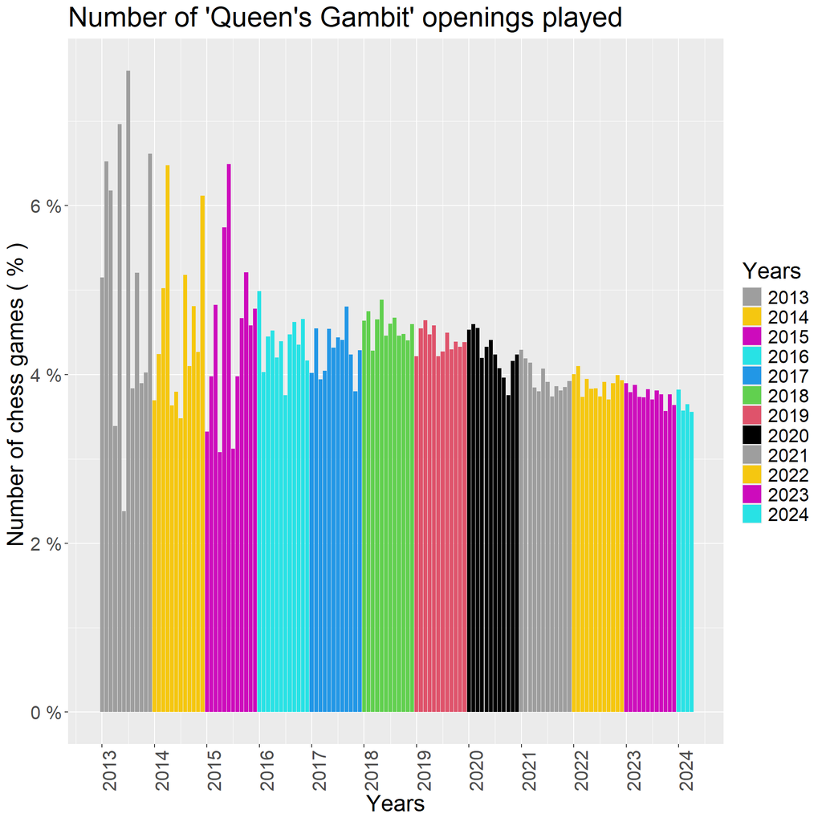

```r
my_Percent_games_count <- data.frame(count=Percent_games_count)

Data_Queens_gambit_games_count = cbind(data.frame(year=year_from_imported_links),my_Percent_games_count)

ggplot(Data_Queens_gambit_games_count, aes(x = rev(1:length(games_count)), y = count)) +

  # typ wykresu
  geom_bar(stat = "identity",aes(fill = year)) +

  # opis
  labs(x = "Years", y = "Number of chess games ( % ) ", title = "Number of 'Queen's Gambit' openings played") +

  # legenda
  scale_fill_manual(name = "Years", values = unique(Data_Queens_gambit_games_count$year)) +
  expand_limits(x = c(0, NA), y = c(0,NA)) +
  scale_x_continuous(breaks = c(rev(first_index_of_years)),
                     labels = c(rev(unique(year_from_imported_links)))) +
  scale_y_continuous(labels = unit_format(unit = "%", scale = 1)) +
  theme(text = element_text(size = 20),
        axis.text.x = element_text(angle = 90, hjust = 1))
```

```r
ggsave("../poster/Data_Queens_gambit_games_count.png")
```

### Obserwacje:

- Widać wyraźnie malejący stosunek granych debiutów “Gambit królowej”, po dacie premiery serialu.

### Wnioski:

- Serial znacząco zwiększył popularność szachów, wśród osób, które nie wiedzą co znaczy termin “Gambit królowej”.

# Czy serial wpłynął tylko na nowicjuszy szachowych?

### Wyszukiwanie Ilości zagranych partii przez nowicjuszy (ranga < 1200)

```r
files_to_read = paste(Dataset_path,"/",year_from_imported_links,"/",month_from_imported_links,". ",my_month_names,"/Data_",full_date_from_imported_links,".pgn", sep="")

novice_games_count=c()

for(i in 1:length(files_to_read)){
  pgn <- read.table(files_to_read[i], quote="", sep="\n", stringsAsFactors=FALSE)

  pgn.df <- data.frame(matrix(sub("\\[\\w+ \\\"(.+)\\\"\\]", "\\1", pgn[,1]),
                              byrow=TRUE, ncol=1))

  elo_index = which(sub("\\[(\\w+).+", "\\1", pgn[1:nrow(pgn.df),1]) == "WhiteElo")

  All_games_count = length(pgn.df[elo_index,])

  my_novice_games_count = length(which(as.numeric(pgn.df[elo_index,]) < 1200) == TRUE)

  novice_games_count = append(novice_games_count,(my_novice_games_count/All_games_count)*100)
}
```

### Wizualizacja

[figure not shown]

```r
my_Percent_novice_games_count <- data.frame(count=Percent_novice_games_count)

Data_novice_games_count = cbind(data.frame(year=year_from_imported_links),my_Percent_novice_games_count)

ggplot(Data_novice_games_count, aes(x = rev(1:length(games_count)), y = count)) +

  # typ wykresu
  geom_bar(stat = "identity",aes(fill = year)) +

  # opis
  labs(x = "Years", y = "Number of chess games ( % ) ", title = "Number of novice games (rank < 1200) ") +

  # legenda
  scale_fill_manual(name = "Years", values = unique(Data_novice_games_count$year)) +
  expand_limits(x = c(0, NA), y = c(0,NA)) +
  scale_x_continuous(breaks = c(rev(first_index_of_years)),
                     labels = c(rev(unique(year_from_imported_links)))) +
  scale_y_continuous(labels = unit_format(unit = "%", scale = 1)) +
  theme(text = element_text(size = 20),
        axis.text.x = element_text(angle = 90, hjust = 1))  +

  # strzalka
  geom_segment(aes(58, 10.68, xend = 95, yend = 10),
               linewidth=1.2,
               arrow = arrow(length = unit(5, "mm"))) +

  # zdjecia
    inset_element(p = img,
                left = 0.02,
                bottom = 0.54,
                right = 0.42,
                top = 0.9)
```

```r
ggsave("../poster/Data_novice_games_count.png")
```

### Obserwacje:

- Widać znaczny napływ nowicjuszy po dacie premiery serialu

### Wniosek:

- Po oglądnięciu serialu, osoby, które nie znają się na szachach, chcą po prostu zagrać w tę grę i nie interesują się debiutami. To powoduje chęć zagrania na stronie lichess jako nowicjusz.

### Wyszukiwanie Ilości zagranych partii przez zaawansowanych graczy (ranga > 1800)

```r
files_to_read = paste(Dataset_path,"/",year_from_imported_links,"/",month_from_imported_links,". ",my_month_names,"/Data_",full_date_from_imported_links,".pgn", sep="")

pro_games_count=c()

for(i in 1:length(files_to_read)){
  pgn <- read.table(files_to_read[i], quote="", sep="\n", stringsAsFactors=FALSE)

  pgn.df <- data.frame(matrix(sub("\\[\\w+ \\\"(.+)\\\"\\]", "\\1", pgn[,1]),
                              byrow=TRUE, ncol=1))

  elo_index_v2 = which(sub("\\[(\\w+).+", "\\1", pgn[1:nrow(pgn.df),1]) == "WhiteElo")

  All_games_count_v2 = length(pgn.df[elo_index_v2,])

  my_pro_games_count = length(which(as.numeric(pgn.df[elo_index_v2,]) > 1800) == TRUE)

  pro_games_count = append(pro_games_count,(my_pro_games_count/All_games_count_v2)*100)
}
```

### Wizualizacja

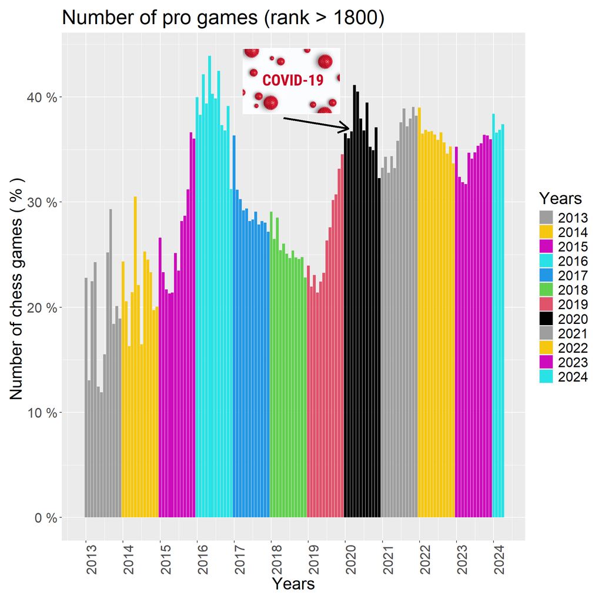

```r
my_Percent_pro_games_count <- data.frame(count=Percent_pro_games_count)

Data_pro_games_count = cbind(data.frame(year=year_from_imported_links),my_Percent_pro_games_count)

ggplot(Data_pro_games_count, aes(x = rev(1:length(games_count)), y = count)) +

  # typ wykresu
  geom_bar(stat = "identity",aes(fill = year)) +

  # opis
  labs(x = "Years", y = "Number of chess games ( % ) ", title = "Number of pro games (rank > 1800) ") +

  # legenda
  scale_fill_manual(name = "Years", values = unique(Data_pro_games_count$year)) +
  expand_limits(x = c(0, NA), y = c(0,NA)) +
  scale_x_continuous(breaks = c(rev(first_index_of_years)),
                     labels = c(rev(unique(year_from_imported_links)))) +
  scale_y_continuous(labels = unit_format(unit = "%", scale = 1)) +
  theme(text = element_text(size = 20),
        axis.text.x = element_text(angle = 90, hjust = 1))  +

  # strzalka
  geom_segment(aes(65, 38, xend = 86, yend = 37),
               linewidth=1.2,
               arrow = arrow(length = unit(5, "mm"))) +
  inset_element(p = img3,
                left = 0.39,
                bottom = 0.84,
                right = 0.6,
                top = 0.97)
```

```r
ggsave("../poster/Data_pro_games_count.png")
```

### Wnioski:

- Serial wpłynął na popularyzacje szachów, głównie zachęcając do gry nowicjuszy.

# Dla czego serial nie wpłynął na zaawansowanych graczy?

- Nie zawierał dla nich nic nowego

# Czy dodanie do szachów nowości wpłynie na zaawansowanych graczy?

#### Tworzenie nowego debiutu

[figure not shown]

#### Statystyki popularności Anny Cramling na twitch

[figure not shown]

[figure not shown]

### Obserwacje:

##### Widać wyraźny wzrost popularności streamerki:

- kiedy opublikowała swój debiut szachowy na youtube
- kiedy na stronie chess.com dodano jej debiut do bazy danych

### Wyszukiwanie debiutów po sekwencji posunięć, zamiast po nazwie

#### Wcześniejsza wersja kodu

```r
# filtred_two_moves_to_compare = two_moves_to_compare[c(5,6) + rep(seq(0, length(two_moves_to_compare), 6), each = 2)]

# files_to_read = paste(Dataset_path,"/",year_from_imported_links,"/",month_from_imported_links,". ",my_month_names,"/Data_",full_date_from_imported_links,".pgn", sep="")

my_opening=c()

for(i in 1:1){
  pgn <- read.table(files_to_read[i], quote="", sep="\n", stringsAsFactors=FALSE)

  moves = which(sub("\\[(\\b+).+", "\\1", pgn[1:nrow(pgn),1]) != "")
  head(moves)
  my_five_moves = unlist(stri_match_all(pgn[moves,], regex = "1. \\s*(.*?)\\s* 6. "))
  head(my_five_moves)
  filtred_five_moves = my_five_moves[seq(1,length(my_five_moves), by=2)]
  head(filtred_five_moves)

  my_opening_index=c()

  for(i in 1:length(filtred_five_moves)){
  five_moves_to_compare = stri_match_all(filtred_five_moves, regex = "(\\d. (\\w+))")[[i]][,3]
  ifelse(setequal(five_moves_to_compare,c("e3","d3","Ne2","Nd2","Ng3"))== TRUE,
         (my_opening_index = append(my_opening_index,i)),
         next)
  }
```

#### Java-script dla przycisku

```javascript
const searching_v1_div = document.getElementById("searching_v1_div");
  searching_v1_div.style.display = 'none';

var searching_v1 = document.getElementById("searching_v1");

function searching() {
  if (searching_v1_div.style.display === 'none') {
    searching_v1_div.style.display = 'block';
    searching_v1.innerHTML = "Ukryj kod";
  } else {
    searching_v1_div.style.display = 'none';
    searching_v1.innerHTML = "Pokaż kod";
  }
}
```

#### Nowsza wersja kodu

```r
#files_to_read = paste(Dataset_path,"/",year_from_imported_links,"/",month_from_imported_links,". ",my_month_names,"/Data_",full_date_from_imported_links,".pgn", sep="")

search_by_moves = function(searching_moves){
  opening_count=c()

  for(i in 1:length(files_to_read)){
    pgn <- read.table(files_to_read[i], quote="", sep="\n", stringsAsFactors=FALSE)

    moves = which(sub("\\[(\\b+).+", "\\1", pgn[1:nrow(pgn),1]) != "")

    All_games_count = length(pgn[moves,])

    for(j in 1:length(searching_moves)){
      my_regex = paste("(.*?)\\s*",j,". (\\w+).+", sep = "")
      moves_to_compare = sub(my_regex, "\\2", pgn[moves,])
      moves = moves[which(moves_to_compare == searching_moves[j])]
    }

    opening_count = append(opening_count,(length(moves)/All_games_count)*100)
  }
  return(opening_count)
}

search_by_moves(c("e3","d3","Ne2","Nd2","Ng3"))
```

### Wizualizacja

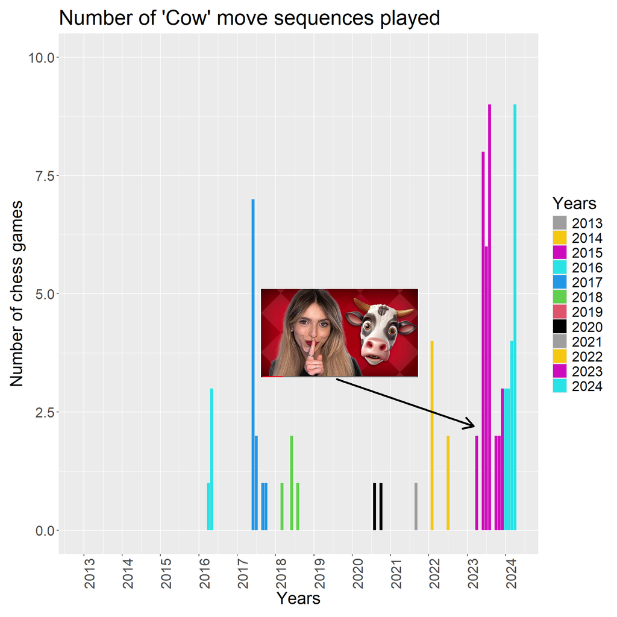

```r
my_opening_count <- data.frame(count=opening_count)

Data_opening_count = cbind(data.frame(year=year_from_imported_links),my_opening_count)

ggplot(Data_opening_count, aes(x = rev(1:length(games_count)), y = count)) +

  # typ wykresu
  geom_bar(stat = "identity",aes(fill = year)) +

  # opis
  labs(x = "Years", y = "Number of chess games", title = "Number of 'Cow' move sequences played") +

  # legenda
  scale_fill_manual(name = "Years", values = unique(Data_opening_count$year)) +
  expand_limits(x = c(0, NA), y = c(0, 10)) +
  scale_x_continuous(breaks = c(rev(first_index_of_years)),
                     labels = c(rev(unique(year_from_imported_links)))) +
  theme(text = element_text(size = 20),
        axis.text.x = element_text(angle = 90, hjust = 1))  +

  # strzalka
  geom_segment(aes(80, 3.2, xend = 123, yend = 2.2),
               linewidth=1.2,
               arrow = arrow(length = unit(5, "mm"))) +
  inset_element(p = img4,
                left = 0.42,
                bottom = 0.34,
                right = 0.75,
                top = 0.51)
```

```r
ggsave("../poster/Data_opening_count.png")
```

### Obserwacje:

- Widać wzrost popularności streamerki po opublikowaniu nowego debiutu oraz widać wzrost zainteresowania jej stworzoną sekwencją szachową

### Wnioski:

- Dodawanie do szachów nowości wpływa na aktywizacje zaawansowanych graczy

# Podsumowanie

### Internet i media społecznościowe znacząco wpływają na popularyzacje szachów, jednak z różnym natężeniem w zależności od tego, na jak zaawansowaną grupe oddziałowuje

# Zastosowanie prezentacji

### Tworzenie treści w internecie

- Podczas publikowania treści w internecie, należy być świadomym, że zawsze istnieją grupy, które są zaznajomione z tematyką treści oraz grupy, dla których tworzona treść jest całkowicie nowa.
- Należy więc w miarę możliwości dostosować tworzone treści dla obu tych grup.
- Przykładem mogą być tworzone poradniki na youtube o tematyce programowania. Nie cieszą się wielką popularnością, ponieważ są skierowane tylko dla osób zaznajomionych z tematyką programowania.

### Wyszukiwanie partii względem wybranej sekwencji

```r
files_to_read = paste(Dataset_path,"/",year_from_imported_links,"/",month_from_imported_links,". ",my_month_names,"/Data_",full_date_from_imported_links,".pgn", sep="")

search_games_by_moves = function(searching_moves, months_to_search){
  openings=data.frame()

  for(i in 1:months_to_search){
    pgn <- read.table(files_to_read[i], quote="", sep="\n", stringsAsFactors=FALSE)

    moves = which(sub("\\[(\\b+).+", "\\1", pgn[1:nrow(pgn),1]) != "")

    for(j in 1:length(searching_moves)){
      my_regex = paste("(.*?)\\s*",j,". (\\w+).+", sep = "")
      moves_to_compare = sub(my_regex, "\\2", pgn[moves,])
      moves = moves[which(moves_to_compare == searching_moves[j])]
    }

    for(z in 1:length(pgn[moves,])){
      moves_detect_whiteV1 = stri_match_all(pgn[moves,], regex = "(\\d. (\\w+))")[[z]][,3]
      moves_detect_white = paste(1:length(moves_detect_whiteV1),". ",moves_detect_whiteV1, sep = "")

      moves_detect_blackV1 = stri_match_all(pgn[moves,], regex = "(\\d.\\.. (\\w+))")[[z]][,3]
      moves_detect_black = paste(1:length(moves_detect_blackV1),"... ",moves_detect_blackV1, sep = "")

      opening_moves = numeric(length(moves_detect_white)+length(moves_detect_black))

      opening_moves[seq(1, length(opening_moves), by=2)] <- moves_detect_white
      opening_moves[seq(2, length(opening_moves), by=2)] <- moves_detect_black

      openings = rbind(openings,moves=paste(opening_moves, collapse = " "))
    }
    colnames(openings) = "moves"

  }
  return(openings)
}

pander(head(search_games_by_moves(c("Nf3","Ng1"),1)))
```

| moves |
| --- |
| 1. Nf3 1… d5 2. Ng1 2… Nf6 3. Nf3 3… Bf5 4. Ng1 4… e6 5. e3 5… Be7 6. d4 6… O 7. Nf3 7… c5 8. Bd3 8… Nc6 9. Bxf5 9… exf5 10. O 10… Ne4 11. c3 11… Re8 12. Nbd2 12… a5 13. Nb3 13… Qb6 14. dxc5 14… Nxc5 … |
| 1. Nf3 1… c5 2. Ng1 2… g6 3. Nf3 3… Bg7 4. Ng1 4… Nc6 5. Nf3 5… d5 6. Ng1 6… Nf6 7. Nf3 7… O 8. d3 8… e5 9. g3 9… Qe7 10. Bg2 10… Be6 11. Nbd2 11… a5 12. c4 12… d4 13. b3 13… Rab8 14. O 14… b5 15. Re1… |
| 1. Nf3 1… e6 2. Ng1 2… Bc5 3. Nf3 3… d6 4. e3 4… Nf6 5. d4 5… Bb6 6. Bd2 6… c5 7. Nc3 7… cxd4 8. exd4 8… Ng4 9. h3 9… Nf6 10. Qe2 10… Ba5 11. O 11… Qc7 12. Qe3 12… d5 13. Ne5 13… Ne4 14. Nb5 14… Bxd2 … |
| 1. Nf3 1… d5 2. Ng1 2… e5 3. g3 3… e4 4. Bg2 4… f5 5. e3 5… f4 6. d3 6… f3 7. Bf1 7… c6 8. dxe4 8… dxe4 9. Qxd8 9… Kxd8 10. Nc3 10… Nf6 11. Bd2 11… Bf5 12. Bc4 12… Nbd7 13. O 13… b5 14. Bb3 14… Kc7 15… |
| 1. Nf3 1… c5 2. Ng1 2… d5 3. g3 3… d4 4. Bg2 4… Bg4 5. d3 5… Bxe2 6. Qxe2 6… Nc6 7. Nf3 7… Nb4 8. O 8… Nf6 9. a3 9… Nc6 10. Qd2 10… e6 11. Qd1 11… Bd6 12. Bg5 12… O 13. h4 13… h6 14. Bxf6 14… Qxf6 15.… |
| 1. Nf3 1… e6 2. Ng1 2… Be7 3. f4 3… d6 4. Nf3 4… c6 5. e3 5… b6 6. d4 6… Bb7 7. Bd3 7… Nd7 8. O 8… Ngf6 9. c3 9… O 10. Bc2 10… c5 11. Nbd2 11… cxd4 12. exd4 12… e5 13. Nb1 13… exf4 14. Bxf4 14… Nd5 15… |